# 東京都の電力需要予測

shoma

# 問題の確認

日々の電力需要量は気象などの影響に左右されている。日々の最高気温・雨量などか ら電力需要を機械学習により予測するモデルを作成する。

1. 東京電力の公開する過去の電力使用実績のページ https://www.tepco.co.jp/ forecast/html/download-j.html から, 2017 年, 2018 年, 2019 年, 2020 年, 2021 年 のデータをダウンロードする.そして、適切にデータを処理し、すべて bind rows 関 数で縦にマージし, その後 DATE を日付型にする.
2. 1のデータは 1 時間ごとの電力需要なので, これを日ごとに合計して 1 日の電力需要を 求める. そして, 1 日の電力需要の変化を折れ線グラフで表し, 考察する.
3. 次のURLからデータをダウンロードする.https://www.math.chuo-u.ac.jp/~sakaori/data/weather2017-21.csv
   1. と同様に適切にスキップして（各列の名前が自動的に適切に入るように）読み込み を行う. 不要な行を削除し, 変数名を適切に変更しながら「年月日」「平均気温」「最高 気温」「最低気温」「降水量」「日照時間」「平均湿度」「天気」のみを残し,
   2. と同様に 「年月日」を日付型に変更する. そして, (1) のデータフレームと今作成したデータフレームを結合する. 最後に, 「月」「日」「曜日」という変数を作成する.なお「月」と「日」が数値になってしまうので文字型 character にする.
4. 2017 年, 2018 年のデータを train, 2019 年のデータを test として, いくつかの機械学 習の方法を用いて電力需要を当日の気象から予測する, できる限り精度の高いモデルを 作成し, 比較・考察する.
5. 2017 年, 2018 年, 2019 年のデータを train, 2020 年のデータを test として, いくつか の機械学習の方法を用いて電力需要を当日の気象から予測する. モデルを作成し, 比較・考察を行う. 新型コロナウイルスの影響で活動様式がそれ までとは大きく異なった 2020 年の予測もうまくできているかを確認する. また, train は 変更せず, 2021 年のデータを test とした場合はどうなるかを確かめる.

# 問題１

## データの読み込み

不要な行が先頭に2列あったためskip=2とした。また、ファイルのエンコーディングがUTF-8ではなくshift_JISであったためそのようにエンコーディングを変更して読み込みを行った。

```r
library("tidyverse")

ele2017<-read_csv("juyo-2017.csv",skip = 2 ,locale = locale(encoding = "Shift_JIS"))
ele2018<-read_csv("juyo-2018.csv",skip = 2 ,locale = locale(encoding = "Shift_JIS"))
ele2019<-read_csv("juyo-2019.csv",skip = 2 ,locale = locale(encoding = "Shift_JIS"))
ele2020<-read_csv("juyo-2020.csv",skip = 2 ,locale = locale(encoding = "Shift_JIS"))
ele2021<-read_csv("juyo-2021.csv",skip = 2 ,locale = locale(encoding = "Shift_JIS"))
```

## 処理したデータの結合

bind_rowsを使ってデータの結合を行った。そして、作られたデータを示す。

```r
data<-bind_rows(ele2017,ele2018,ele2019,ele2020,ele2021)
data
```

```
## # A tibble: 43,824 × 3
##    DATE     TIME   `実績(万kW)`
##    <chr>    <time>        <dbl>
##  1 2017/1/1 00:00          2783
##  2 2017/1/1 01:00          2634
##  3 2017/1/1 02:00          2520
##  4 2017/1/1 03:00          2438
##  5 2017/1/1 04:00          2389
##  6 2017/1/1 05:00          2394
##  7 2017/1/1 06:00          2491
##  8 2017/1/1 07:00          2626
##  9 2017/1/1 08:00          2715
## 10 2017/1/1 09:00          2637
## # ℹ 43,814 more rows
```

## DATEのデータ型の変更

```r
install.packages("lubridate")
library("lubridate")
data1<-data %>% mutate(DATE = ymd(DATE))
```

# 問題２

問題1で作ったデータをから一日の電力需要量を求める.この時の結果のデータを示す.

```r
data_all<-data1 %>% group_by(DATE) %>% summarize(elec = sum(`実績(万kW)`))
data_all
```

```
## # A tibble: 1,826 × 2
##    DATE        elec
##    <date>     <dbl>
##  1 2017-01-01 62234
##  2 2017-01-02 63592
##  3 2017-01-03 65243
##  4 2017-01-04 71644
##  5 2017-01-05 81938
##  6 2017-01-06 88836
##  7 2017-01-07 85318
##  8 2017-01-08 83725
##  9 2017-01-09 81743
## 10 2017-01-10 86621
## # ℹ 1,816 more rows
```

そして、電力需要を可視化する.

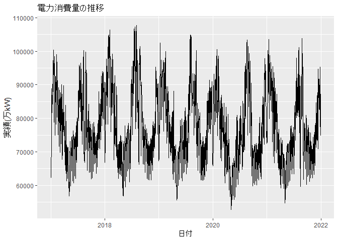

```r
data_all %>% ggplot(aes(DATE,elec))+geom_line()+labs(title = "電力消費量の推移", x = "日付", y = "実績(万kW)")
```

## 電力消費量に対する考察

1月、2月、8月、9月あたりの電力需要がでかくなっていることがわかった。そして、それが各年に周期的に繰り返されていることがわかった。寒い時期や暑い時期といった冷暖房機器を使う時期に消費量が多くなっていると考えらえられた。また、2018年が最も寒暖差の激しい年であったことが考えられた。

# 問題３

## 気象データの読み込み＆不要データの処理

```r
weather<-read_csv("weather2017-21.csv",skip=3,locale = locale(encoding = "Shift_JIS"))
```

[output not shown]

```r
weather<-weather[-c(1,2),]
weather_new<-weather[,-c(3,4,6,7,8,10,11,12,14,15,17,18,20,21,23,24)]
```

## カラムの名称変更

```r
names(weather_new)[1]<-"DATE"
names(weather_new)[2]<-"ave_temp"
names(weather_new)[3]<-"rain_sum"
names(weather_new)[4]<-"shiny"
names(weather_new)[5]<-"ave_humid"
names(weather_new)[6]<-"heigh_temp"
names(weather_new)[7]<-"low_temp"
names(weather_new)[8]<-"weth_for"
```

## 問題１で作ったデータと気象データの結合

```r
bind_cols(weather_new,data_all)
```

```
## # A tibble: 1,826 × 10
##    DATE...1  ave_temp rain_sum shiny ave_humid heigh_temp low_temp weth_for
##    <chr>        <dbl>    <dbl> <dbl>     <dbl>      <dbl>    <dbl> <chr>
##  1 2017/1/1       7.4      0     8.9        59       13.8      2   快晴
##  2 2017/1/2       7.2      0     6.5        65       13.3      3.8 晴一時曇
##  3 2017/1/3       8        0     8.2        54       13.7      3.5 快晴
##  4 2017/1/4       8.5      0     8.7        48       14        3.6 快晴
##  5 2017/1/5       6.7      0     9          39       10.4      3.7 快晴
##  6 2017/1/6       4.5      0     8.8        48        8.8      1.5 晴一時薄曇
##  7 2017/1/7       4.1      0     8.7        55        8.7      0.1 晴
##  8 2017/1/8       3.9     20.5   0          76        6        1.6 曇時々雨
##  9 2017/1/9       7.2      5.5   2.2        85       11.1      3.8 雨後晴
## 10 2017/1/10      8.1      0     8.9        61       12.7      3.5 快晴
## # ℹ 1,816 more rows
## # ℹ 2 more variables: DATE...9 <date>, elec <dbl>
```

```r
weather_new<-weather_new %>% mutate(DATE = ymd(DATE))
```

```r
complete_data<-merge(weather_new,data_all,by="DATE")
complete_data<-complete_data %>%
  mutate(month = month(DATE),day = day(DATE),weekdays = weekdays(DATE)) %>%
  mutate(day = as.character(day),month = as.character(month))
```

天気予報データをfactor変数にする

```r
complete_data$weth_for<-as.factor(complete_data$weth_for)
```

# 問題４

2017年, 2018年のデータを訓練データ,2019年のデータをテストデータとして機械学習モデルをいくつか作り比較考察を行う。

```r
library("caret")
```

## データの作成

```r
train_data<-complete_data %>% filter(DATE >= as.Date("2017-01-01")& DATE <= as.Date("2018-12-31"))
test_data <- complete_data %>% filter(DATE >= as.Date("2019-01-01")&DATE <= as.Date("2019-12-31"))
```

```r
training<-train_data[,-c(12,11,10,1)]
testing<-test_data[,-c(12,11,10,1)]
```

日付、月、日、曜日のデータを除いた訓練データとテストデータを作った。

## 機械学習モデル

### 重回帰モデルを作って、AICによる変数選択を行う。

```r
kaiki_lm<-lm(elec~.,data = training)
kaiki_step<-step(kaiki_lm)
```

```
## Start:  AIC=13549.56
## elec ~ ave_temp + rain_sum + shiny + ave_humid + heigh_temp +
##     low_temp + weth_for
##
##              Df  Sum of Sq        RSS   AIC
## - weth_for   88 1.0911e+10 7.5661e+10 13487
## - heigh_temp  1 4.7622e+06 6.4755e+10 13548
## - rain_sum    1 3.0119e+07 6.4781e+10 13548
## - shiny       1 4.0142e+07 6.4791e+10 13548
## <none>                     6.4751e+10 13550
## - ave_humid   1 2.4525e+08 6.4996e+10 13550
## - ave_temp    1 4.8610e+08 6.5237e+10 13553
## - low_temp    1 1.4855e+09 6.6236e+10 13564
##
## Step:  AIC=13487.24
## elec ~ ave_temp + rain_sum + shiny + ave_humid + heigh_temp +
##     low_temp
##
##              Df  Sum of Sq        RSS   AIC
## - heigh_temp  1  116602153 7.5778e+10 13486
## <none>                     7.5661e+10 13487
## - ave_humid   1  259016993 7.5921e+10 13488
## - rain_sum    1  359100409 7.6021e+10 13489
## - shiny       1  609466094 7.6271e+10 13491
## - ave_temp    1 1170672143 7.6832e+10 13496
## - low_temp    1 2392264524 7.8054e+10 13508
##
## Step:  AIC=13486.36
## elec ~ ave_temp + rain_sum + shiny + ave_humid + low_temp
##
##             Df  Sum of Sq        RSS   AIC
## <none>                    7.5778e+10 13486
## - ave_humid  1  253951750 7.6032e+10 13487
## - rain_sum   1  364587865 7.6143e+10 13488
## - shiny      1  862445578 7.6641e+10 13493
## - low_temp   1 2865599987 7.8644e+10 13512
## - ave_temp   1 3051517056 7.8830e+10 13513
```

```r
kaiki.pred <- predict(kaiki_step,testing)
postResample (pred = kaiki.pred,obs = testing$elec )
```

```
##         RMSE     Rsquared          MAE
## 9.986580e+03 5.314243e-02 8.074256e+03
```

モデルの訓練方法を5foldクロスバリデーションで行うようにした

```r
trctrl <- trainControl (method ="cv" , number =5)
kaiki1<- train(elec~ave_humid+rain_sum+shiny+low_temp+ave_temp,data = training,method = "lm",trControl = trctrl)
kaiki1
```

```
## Linear Regression
##
## 730 samples
##   5 predictor
##
## No pre-processing
## Resampling: Cross-Validated (5 fold)
## Summary of sample sizes: 584, 583, 585, 583, 585
## Resampling results:
##
##   RMSE      Rsquared    MAE
##   10259.64  0.05364398  8397.593
##
## Tuning parameter 'intercept' was held constant at a value of TRUE
```

```r
kaiki1.pred <- predict(kaiki1,testing)
postResample (pred = kaiki1.pred,obs = testing$elec )
```

```
##         RMSE     Rsquared          MAE
## 9.986580e+03 5.314243e-02 8.074256e+03
```

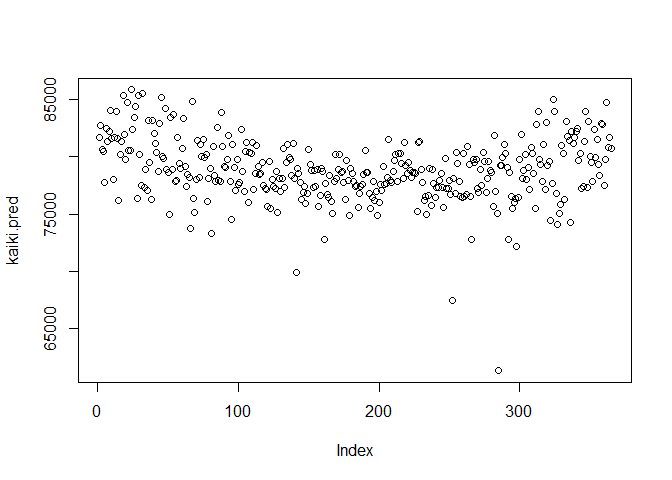

```r
plot(kaiki.pred)
```

### 重回帰モデルに対する考察

重回帰モデルの当てはまりがどちらのモデルともよくないことがわかった。これは重回帰モデルでは電力需要をうまく予測できないことを示していることが考えられた。また、重回帰では電力重要のような周期的かつ曲線的な分布になっているデータを捉えることに向いていないことが考えられた。そのため、変数をさらに増やしたとしてもあまり予測精度が上がらないことが期待される。仮に、モデルの当てはまりがよくなったとしても過学習をしたことによってモデルの当てはまりがよくなったように見えるだけで、汎化性能は落ちることが考えられた。

次に、重回帰モデルより曲線的なデータに対するモデルを構築するのに向いているランダムフォレスト系のモデルを作る手法を用いる。

### XGBOOSTによるモデル

```r
xgb<-train(elec~.,
           data = training ,
           method ="xgbTree",
           trControl = trctrl,
           tuneGrid = expand.grid( max_depth = c (2,3,5) ,
                                  eta = c (0.1 ,0.2),
                                  colsample_bytree = c (0.8 ,0.9),
                                  subsample = c (0.5 ,1) ,
                                  nrounds = c (10,20,50) ,
                                  gamma =c(0,0.1) , min_child_weight =1),
           verbosity = 0)
```

```r
varImp(xgb)
```

```
## xgbTree variable importance
##
##   only 20 most important variables shown (out of 129)
##
##                                Overall
## ave_temp                     1.000e+02
## low_temp                     6.320e+01
## heigh_temp                   9.422e+00
## ave_humid                    2.474e+00
## shiny                        2.010e+00
## rain_sum                     9.717e-01
## weth_for晴一時薄曇           6.414e-01
## weth_for曇一時雪             4.241e-01
## weth_for雨後曇               2.534e-01
## weth_for雨後時々曇           2.246e-01
## weth_for晴後曇               1.542e-01
## weth_for快晴                 1.195e-01
## weth_for薄曇                 1.185e-01
## weth_for大雨時々曇           1.155e-01
## weth_for晴時々薄曇           1.019e-01
## weth_for薄曇時々晴           3.507e-04
## weth_for曇時々雨後晴         0.000e+00
## weth_for曇後一時雨、雷を伴う 0.000e+00
## weth_for晴                   0.000e+00
## weth_for薄曇後晴             0.000e+00
```

```r
xgb.pred<-predict(xgb,testing)
postResample(pred = xgb.pred,obs = testing$elec)
```

```
##         RMSE     Rsquared          MAE
## 5882.0153232    0.6715628 4781.9688142
```

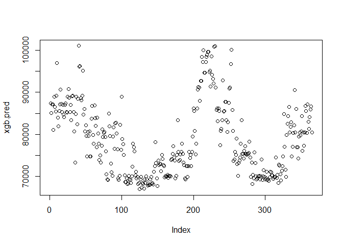

```r
plot(xgb.pred)
```

XGBOOSTのモデルによる予測値と観測値の差が重回帰分析の時よりも小さくなっていることがわかった。これはXGBOOSTの予測値が線形や非線形にとらわれずに一定の情報量基準を小さくすることを目標にモデルを構築しているためであると考えた。そして、重回帰モデルとXGBOOSTのモデルが予測値として算出したデータ点をプロットしたものを比べると明らかにXGBOOSTのモデルの方が曲線的かつ電力需要の曲線にフィットするという事が予測できた。 また、XGBOOSTのモデルの予測値は220から240日のところ（7月から8月）で電力需要の予測値が高くなっているので比較的妥当に予測できていると考えてた。

XGBOOSTの変数重要度を確認し、それに基づいてい変数を選択してモデルを構築する。

また、XGBOOSTで使うパラメータをあらかじめ変数に入れておく。

```r
tunegrid <-expand.grid(max_depth = c(2,3,5),
                        eta = c(0.1 ,0.2),
                        colsample_bytree = c(0.8 ,0.9),
                        subsample = c(0.5 ,1),
                        nrounds = c(20,30,50),
                        gamma =c(0,0.1), min_child_weight =1)
```

変数重要度の上位５つを使い、モデルを作り直す。

```r
xgb_1<-train(elec~ave_temp+low_temp+heigh_temp+shiny+ave_humid,
             data = training,
             method ="xgbTree",
             trControl = trctrl,
             tuneGrid = tunegrid,
             verbosity = 0)

xgb_1.pred<-predict(xgb_1,testing)
postResample(pred = xgb_1.pred,obs = testing$elec)
```

```
##         RMSE     Rsquared          MAE
## 5855.2377690    0.6738566 4763.9266909
```

XGBOOSTの変数重要度を確認し、重要度の高かった変数を説明変数としてモデルを作った方がRMSEの値が小さくなることがわかった。

# 問題５

2017年, 2018年, 2019年のデータを訓練データ, 2020年のデータをテストデータとする。また、訓練データは変えずにテストデータを2021年のデータとする。2パターンのデータを使い機械学習モデルに対する予測精度の違いを見る。

## 訓練データとテストデータの作成

```r
train_data5<-complete_data %>% filter(DATE >= as.Date("2017-01-01")& DATE <= as.Date("2019-12-31"))
test_data5 <- complete_data %>% filter(DATE >= as.Date("2020-01-01")&DATE <= as.Date("2020-12-31"))
test_data6<- complete_data %>% filter(DATE >= as.Date("2021-01-01")&DATE <= as.Date("2021-12-31"))
```

```r
training5<-train_data5[,-c(12,11,10,1)]
testing5<-test_data5[,-c(12,11,10,1)]##2020年
testing6<-test_data6[,-c(12,11,10,1)]##2021年
```

## モデルの作成

### XGBOOSTによるモデル

ハイパーパラメータを事前にいくつか決めておく。

```r
tunegrid <-expand.grid(max_depth = c(2,3,5),
                        eta = c(0.1 ,0.2,0.3),
                        colsample_bytree = c(0.8 ,0.9),
                        subsample = c(0.5 ,1),
                        nrounds = c(20,30,50),
                        gamma =c(0,0.1), min_child_weight =1)
```

先ほどのモデルで変数重要度の高かった変数を使いモデルを構築した。

```r
xgb_5<-train(elec~ave_temp+low_temp+heigh_temp+shiny+ave_humid,
             data = training5,
             method ="xgbTree",
             trControl = trctrl,
             tuneGrid = tunegrid,
             verbosity = 0)
```

```r
xgb_5_all<-train(elec~.,
             data = training5,
             method ="xgbTree",
             trControl = trctrl,
             tuneGrid = tunegrid,
             verbosity = 0)
```

```r
varImp(xgb_5)
```

```
## xgbTree variable importance
##
##             Overall
## ave_temp   100.0000
## low_temp    24.0894
## heigh_temp  15.9339
## shiny        0.2112
## ave_humid    0.0000
```

```r
varImp(xgb_5_all)
```

```
## xgbTree variable importance
##
##   only 20 most important variables shown (out of 129)
##
##                                      Overall
## ave_temp                           100.00000
## low_temp                            25.17109
## heigh_temp                          20.05754
## shiny                                2.06447
## ave_humid                            1.81305
## rain_sum                             0.31173
## weth_for曇一時雪                     0.24834
## weth_for晴一時薄曇                   0.20801
## weth_for曇一時晴後一時雨             0.15056
## weth_for晴一時曇、雷を伴う           0.13639
## weth_for晴後一時曇                   0.10511
## weth_for晴時々薄曇                   0.09266
## weth_for晴後曇                       0.08104
## weth_for快晴                         0.04969
## weth_for薄曇時々晴                   0.04854
## weth_for雨後時々曇                   0.04215
## weth_for大雨時々曇                   0.03512
## weth_for晴時々曇後一時雨、雷を伴う   0.03027
## weth_for薄曇一時雨                   0.02124
## weth_for曇時々雨一時晴               0.00000
```

2020年をテストデータとした時の結果

```r
#####################test2020 5つの変数
xgb_5.pred<-predict(xgb_5,testing5)
postResample(pred = xgb_5.pred,obs = testing5$elec)
```

```
##         RMSE     Rsquared          MAE
## 6462.4465842    0.6731879 5129.2331370
```

```r
#####################test2020 全変数
xgb_5.pred<-predict(xgb_5_all,testing5)
postResample(pred = xgb_5.pred,obs = testing5$elec)
```

```
##         RMSE     Rsquared          MAE
## 6604.4099964    0.6675545 5214.4439464
```

```r
#plot(xgb_5.pred)
```

2021年のデータをテストデータとしたときの結果

```r
#######################test2021　5つの変数

xgb_5_1.pred<-predict(xgb_5,testing6)

postResample(pred = xgb_5_1.pred,obs = testing6$elec)
```

```
##         RMSE     Rsquared          MAE
## 5893.2582582    0.6864824 4848.2027825
```

```r
#######################test2021　全変数
xgb_5_1.pred<-predict(xgb_5_all,testing6)

postResample(pred = xgb_5_1.pred,obs = testing6$elec)
```

```
##         RMSE     Rsquared          MAE
## 5968.4098339    0.6800697 4807.4445634
```

変数を制限したXGBOOSTのモデルから2020年のデータをテストデータとした時の方が2021年のデータをテストデータとした場合よりRMSEの値が大きいことがわかった。つまり、コロナによって生活様式が変化したことによってコロナ前のデータを使った予測がうまくできないことが考えられた。そして、2021年のデータをテストデータとした時の方がRMSEの値が小さいことからコロナ前の生活に戻っていることが考えられた。また、すべての変数をつかったモデルでも同様の傾向が見られた。 二つのモデル（5つの変数を使ったモデルと全変数を使ったモデル）の比較からモデルを作る際には多くの変数を取り入れる方がいいというわけではないという事が考えられた。これは、モデルを作る際に変数を多くしすぎるとモデルが複雑になり過学習しやすくなるという点からも変数選択を適切に行うべきだと考えられた。

### k近傍のモデル

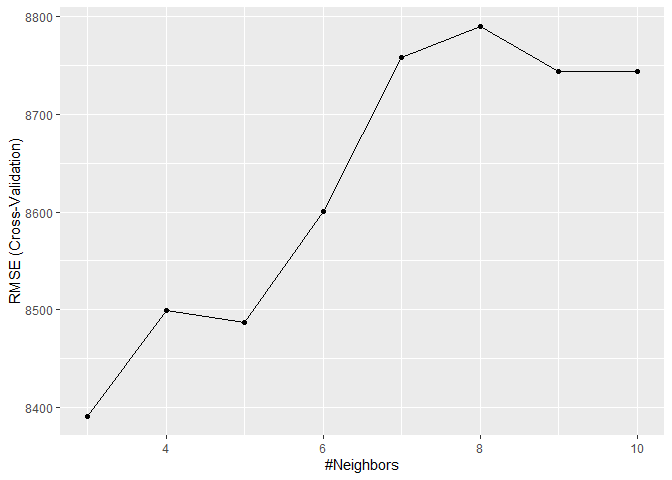

```r
knn<- train(elec~.,data=training,method = "knn",
            preProcess=c("center","scale"),
                       tuneGrid = expand.grid(k = c(3:10)),
            trControl = trctrl)

ggplot(knn)
```

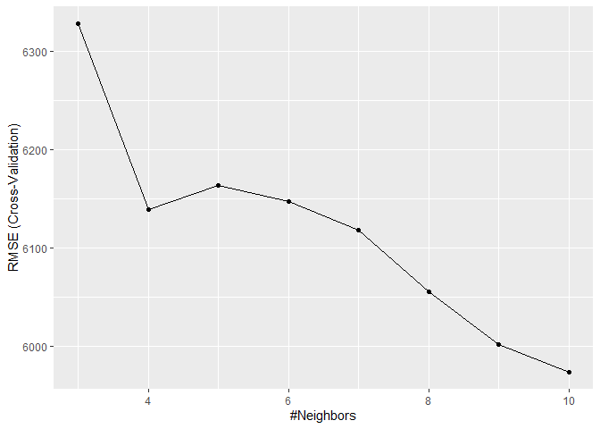

```r
knn1<- train(elec~ave_temp+low_temp+heigh_temp+shiny+ave_humid,
            data=training,method = "knn",
            preProcess=c("center","scale"),
                       tuneGrid = expand.grid(k = c(3:10)),
            trControl = trctrl)

ggplot(knn1)
```

変数を絞ってモデルを作った結果近傍の点の数を増やしても精度が悪くならなくなった。これより、不要な変数を含んでいると近傍点の数を増やしバリアンスを小さくしようとしてもバイアスが大きくなり精度が低くなってしまうことが考えられた。上記の結果からは周りの10この点から予測したときが最も予測精度が高くなることが考えられた。

2020年をテストデータとしたときの結果

```r
##########2020
knn.pred<-predict(knn,testing5)

postResample(pred = knn.pred,obs =testing5$elec )
```

```
##         RMSE     Rsquared          MAE
## 8356.7759402    0.4511608 6504.5412568
```

```r
knn1.pred<-predict(knn1,testing5)#2020変数制限

postResample(pred = knn1.pred,obs =testing5$elec )
```

```
##         RMSE     Rsquared          MAE
## 6683.4252263    0.6669258 5197.0803279
```

2021年をテストデータとした時の結果

```r
#########2021
knn.pred<-predict(knn,testing6)

postResample(pred = knn.pred,obs =testing6$elec )
```

```
##         RMSE     Rsquared          MAE
## 8137.6852922    0.4251492 6323.7844749
```

```r
knn1.pred<-predict(knn1,testing6)#2021変数制限

postResample(pred = knn1.pred,obs =testing6$elec )
```

```
##         RMSE     Rsquared          MAE
## 6113.1214541    0.6682281 4821.4046575
```

k近傍法で求めたRMSEの値は2020年の方が2021より大きいことがわかった。この結果から2020年の生活様式は従来までの生活様式と差があり、2021年は従来の生活様式と2020年ほど差がないことが考えられた。

つまり、コロナによって2020年は以前の生活と同じような様式で生活できていなかったことが考えられた。

一方で、2020年と2021年との比較ではあるので相対的に生活様式が戻ったと捉えることできしかできないと考えた。実際2021年の間もコロナで従来のような生活が行えていなかったため、従来のような生活様式に戻れたと考えるのは適切ではないとも考えた。そのため、2022年のデータをテストデータとして追加してさらに予測の当てはまりがどのようになるかを考えることで、どれ程電力需要の観点から生活様式が戻っているかを捉えやすくなると考えた。